# BIEA Monthly Meeting

February 14, 2018

## Status Report

As of Monday (with 13 BI Embedded Agents)

```
## # A tibble: 5 x 3
##   Course                       Completed Avg.Progress
##   <chr>                            <int>        <dbl>
## 1 The Data Scientist's Toolbox        12         99.6
## 2 R Programming                       10         77.2
## 3 Getting and Cleaning Data            4         62.9
## 4 Exploratory Data Analysis            3         29.6
## 5 Reproducible Research                0         10.4
```

## How's it going?

### What would make this easier next time?

## Outline

1. The Grammar of Graphics and `ggplot2`
2. Q&A
3. Announcements

## The Grammar of Graphics

## Resources

- [A nice explanation](https://ramnathv.github.io/pycon2014-r/visualize/ggplot2.html) of the grammar of graphics
- [`ggplot2` reference](http://ggplot2.tidyverse.org/reference/) (documentation, function references)
- [Elegant graphics for data analysis](https://www.springer.com/us/book/9780387981413) (Hadley Wickham's book on `ggplot2`)
- [Graphics in R](https://srvanderplas.github.io/NPPD-Analytics-Workshop/02.Graphics/02.guide.html) (Training materials from last years' R workshops)
- [R graph catalog](https://github.com/jennybc/r-graph-catalog) - Shiny applet that shows graphs and ggplot2 code for the graph. [Applet](http://shiny.stat.ubc.ca/r-graph-catalog/) (link may not work), [Re-hosted app](http://srvanderplas.com/Shiny/RGraphCatalog/)

## The Grammar of Graphics

- A system for describing graphics
- Breaks the plot down into the following components:
  - Aesthetics: map a variable to something with a scale (x, y, color, shape)
  - Geometries: geometric objects displayed on the chart (point, line, ribbon, rectangle)
  - Scales: control the details of how aesthetics are displayed

## The Grammar of Graphics

- A layer is a set of
  1. data
  2. a mapping of aesthetics
  3. a geometry
- Each plot is made up of one or more layers

## The Grammar of Graphics

(Made up data) Number of people on-site at CNS:

```r
data <- data_frame(
  time = seq(0, 23, 1),
  onsite = c( 30,  30,  30,  30,  45, 156,
             435, 530, 550, 552, 550, 555,
             555, 543, 400, 314, 203,  85,
              45,  42,  32,  30,  30,  30)
)
```

## The Grammar of Graphics

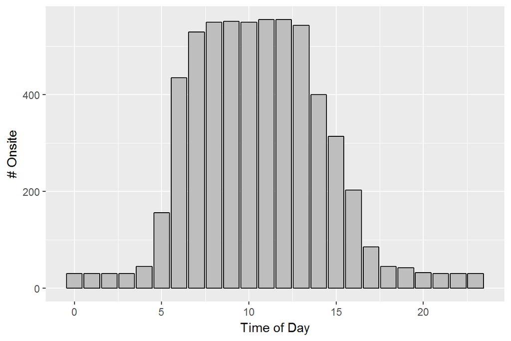

What are the aesthetics? What are the geometric objects?

## The Grammar of Graphics

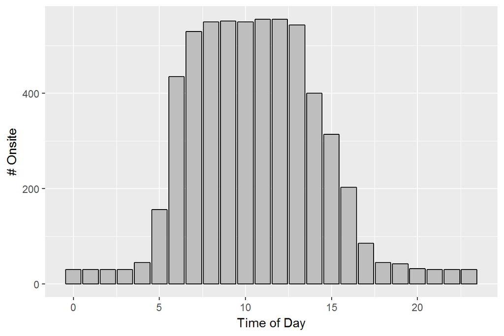

```r
qplot(x = time, weight = onsite, geom = "bar", data = data,
      fill = I("grey"), color = I("black")) +
  xlab("Time of Day") + ylab("# Onsite")
```

## The Grammar of Graphics

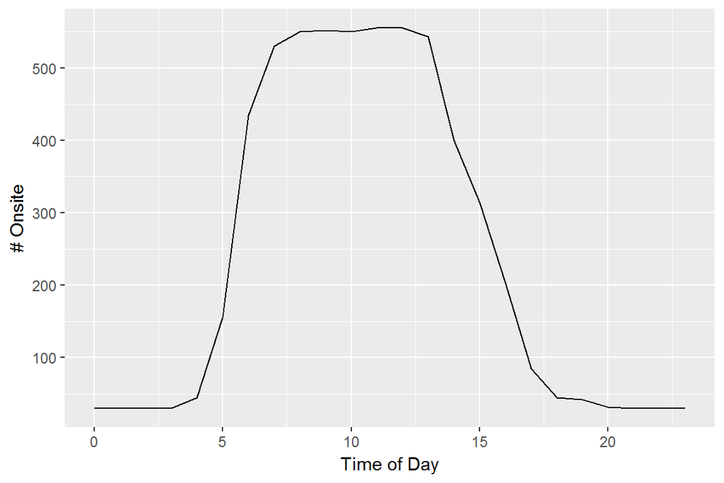

What are the aesthetics? What are the geometric objects?

## The Grammar of Graphics

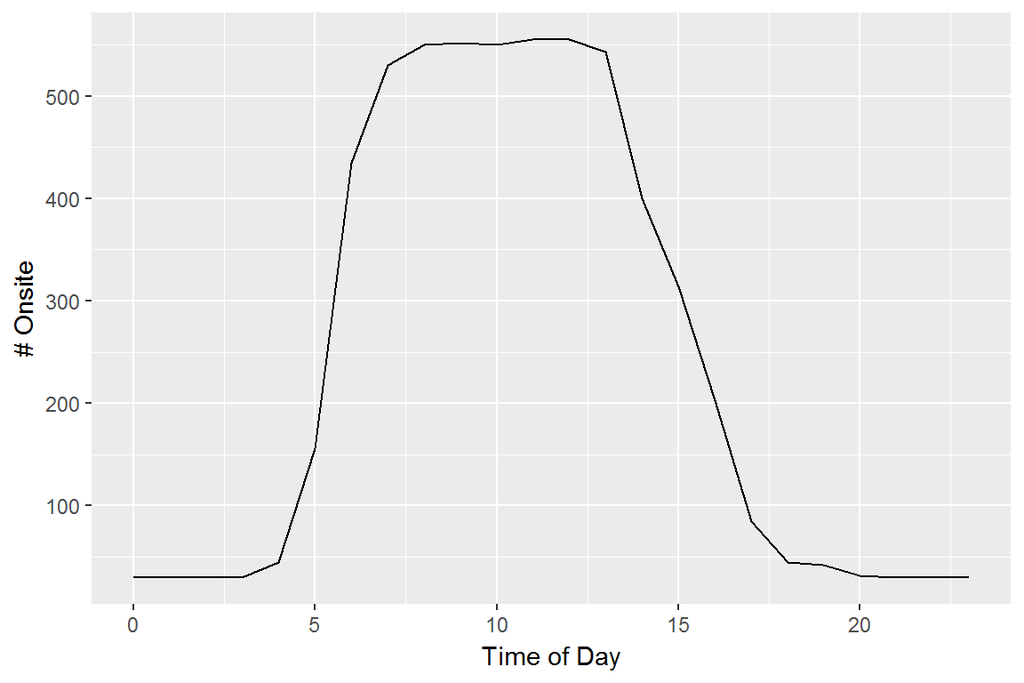

```r
qplot(x = time, y = onsite,
      geom = "line", data = data, color = I("black")) +
  xlab("Time of Day") + ylab("# Onsite")
```

## The Grammar of Graphics

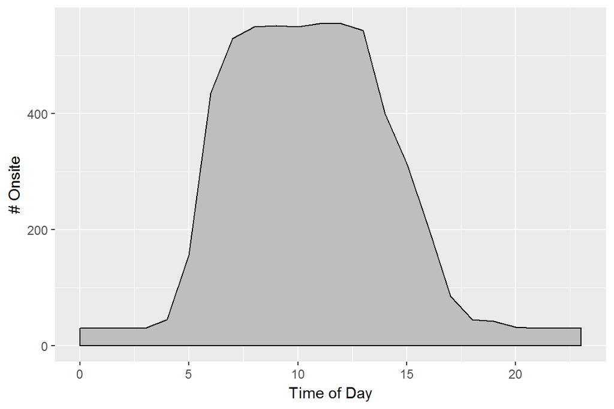

What are the aesthetics? What are the geometric objects?

## The Grammar of Graphics

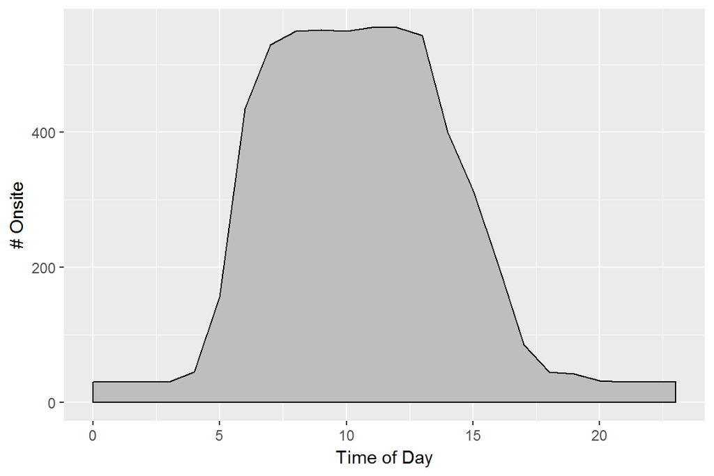

```r
qplot(x = time, ymin = 0, ymax = onsite,
      geom = "ribbon", data = data, fill = I("grey"), color = I("black")) +
  xlab("Time of Day") + ylab("# Onsite")
```

## `ggplot2`

`ggplot2` has two main plotting functions: `qplot` (quickplot) and `ggplot`.

We'll use the diamonds dataset included with `ggplot2` to demonstrate.

qplot makes assumptions about the geometric objects you want:

```r
qplot(carat, price, data = diamonds)
```

ggplot is more precise and can be customized much more extensively

```r
ggplot(data = diamonds) +
  geom_point(aes(x = carat, y = price))
```

## `ggplot2`

Transformations, annotations, and additional layers can be added to both qplot and ggplot using `+`:

```r
qplot(carat, price, data = diamonds) +
  geom_smooth() +
  scale_y_log10() +
  ggtitle("Price of diamonds by weight in carats")


ggplot(data = diamonds) +
  geom_point(aes(x = carat, y = price)) +
  geom_smooth(aes(x = carat, y = price)) +
  scale_y_log10() +
  ggtitle("Price of diamonds by weight in carats")
```

## `ggplot2`

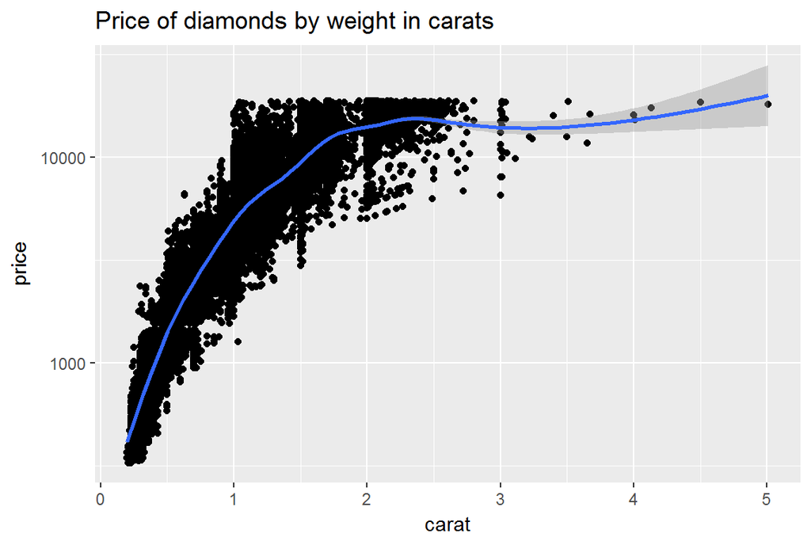

## `ggplot2`

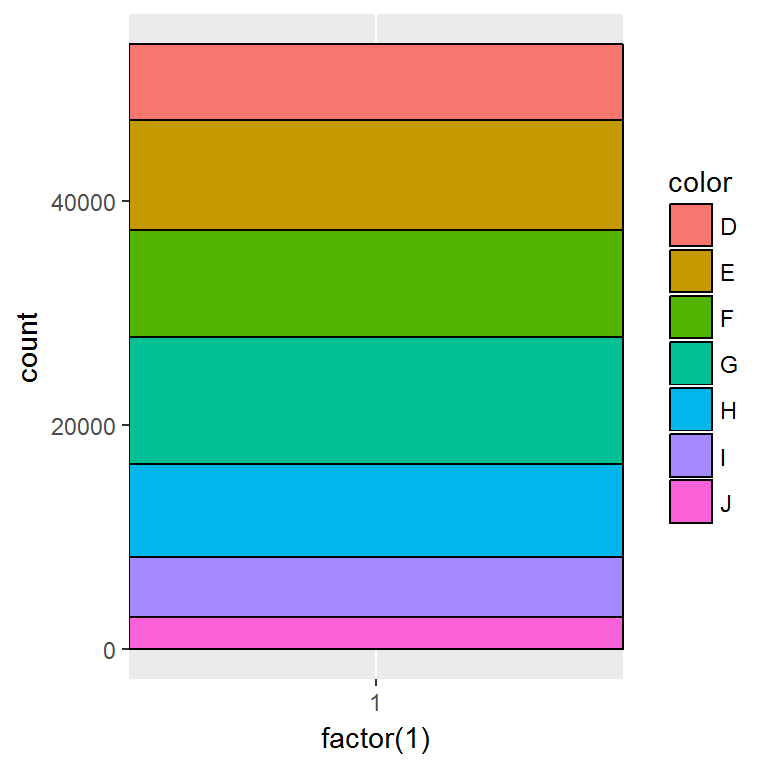

```r
ggplot(data = diamonds, aes(x = factor(1), fill = color)) +
  geom_bar(width = 1, color = "black")
```

## `ggplot2`

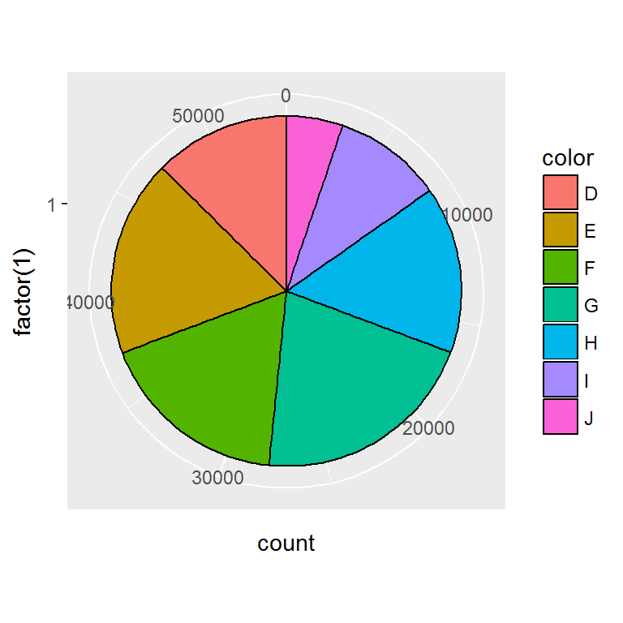

```r
ggplot(data = diamonds, aes(x = factor(1), fill = color)) +
  geom_bar(width = 1, color = "black") +
  coord_polar(theta = 'y')
```

## Example: Coursera Progress

```r
library(stringr) # Work with strings
library(lubridate) # Work with dates
library(tidyr) # Clean up data

csvs <- list.files("\\\\cgownt08\\Common\\BI Embedded Agents", "*.csv",
                   full.names = T)

progress <- lapply(csvs, function(x) {
  tmp <- read.csv(x, stringsAsFactors = F)
  date <- str_extract(x, "\\d{4}-\\d{2}-\\d{2}") %>% ymd()

  tmp$date <- date
  tmp
})
```

## Example: Coursera Progress

```r
progress <- progress %>%
  bind_rows() %>%
  # Remove people who have dropped out or aren't agents
  filter(!External.Id %in% c("cabaler", "gajaspe", "kmhelgo", "jdrosen")) %>%
  # Get variables of interest
  select(Name, Course, Overall.Progress, Completed, date) %>%
  # Add in 0s for all combinations of Name, Course, and date that don't appear
  complete(Name, Course, date, fill = list(Overall.Progress = 0,
                                           Completed = "No")) %>%
  mutate(  # Clean up a bit
    Overall.Progress = ifelse(Completed == "Yes", 100, Overall.Progress),
    Course = str_replace(Course, "The Data Scientist(.*)",
                         "The Data Scientist's Toolbox") %>%
      factor(levels = c("The Data Scientist's Toolbox", "R Programming",
                        "Getting and Cleaning Data", "Exploratory Data Analysis",
                        "Reproducible Research")))  # Set course order
```

## Example: Coursera Progress

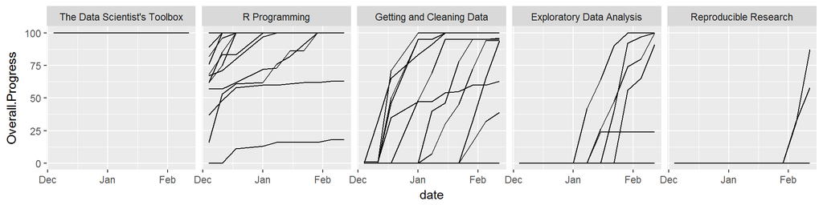

```r
ggplot(data = progress) +
  geom_line(aes(x = date, y = Overall.Progress, group = Name)) +
  facet_wrap(~Course, ncol = 5)
```

## Example: Coursera Progress

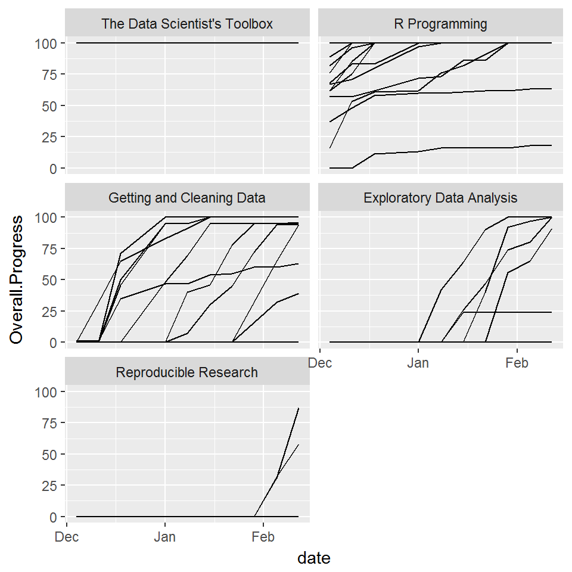

One line per person per course

Most people

- were done with Course 1 before I started logging data
- have completed Course 2 and are on Course 3 or 4

## Example: Coursera Progress

### Color lines by person

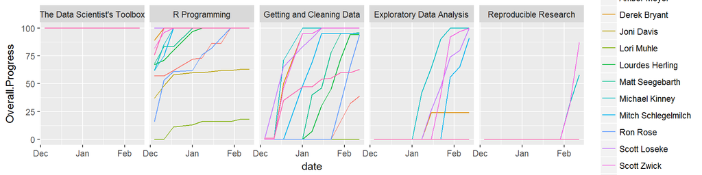

```r
ggplot(data = progress) +
  geom_line(aes(x = date, y = Overall.Progress, color = Name)) +
  facet_wrap(~Course, ncol = 5)
```

## Example: Coursera Progress

### Each person gets a plot

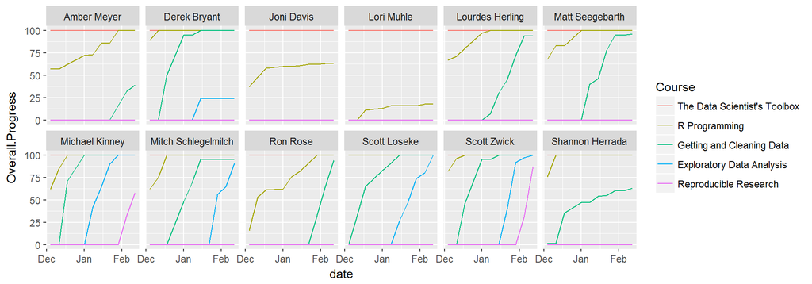

```r
ggplot(data = progress) +
  geom_line(aes(x = date, y = Overall.Progress, color = Course)) +
  facet_wrap(~Name, ncol = 6)
```

## Example: Coursera Progress

### Fill in the area beneath each line

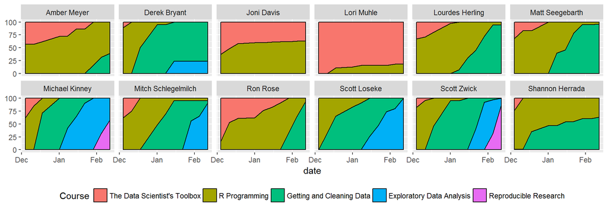

## Example: Coursera Progress

### Fill in the area beneath each line

```r
ggplot(data = progress) +
  geom_ribbon(aes(x = date, ymin = 0, ymax = Overall.Progress, fill = Course),
              color = "black") +
  facet_wrap(~Name, ncol = 6) +
  theme(legend.position = "bottom")
```

## Example: Coursera Progress

### Change the color scheme and move the legend

[figure not shown]

## Example: Coursera Progress

### Change the color scheme and move the legend

```r
ggplot(data = progress) +
  geom_ribbon(aes(x = date, ymin = 0, ymax = Overall.Progress, fill = Course)) +
  facet_wrap(~Name, ncol = 5) +
  guides(fill = guide_legend(nrow = 2)) +
  theme(legend.position = c(1, 0), legend.justification = c(1, 0)) +
  scale_fill_brewer(palette = "Paired")
```

## Q&A

## What R questions do you have for me?

## Announcements

## Next Week

Weather permitting, I will be in Columbus next week for the R Study Group (Wednesday, Feb 21, 8:30 - 9:30).

## Announcement

I have taken a research job at Iowa State University, starting March 1

I will be researching statistical methods for forensics:

- bullet matching
- handwriting analysis
- shoe print matching
- jury response to data and graphics

[figure not shown]

## Wait, What?

- I will still be supporting the BIEA program at NPPD part time
  - I will probably be less available during business hours
  - I'm planning to check in most evenings after I put my son to bed  
    I'll adjust this after I get some sort of routine going long-term
- I will still be available on Slack (even during the day) and reachable by email
  - You can also call my cell phone (515) 509-6613 with urgent questions

### Jason and I are committed to keeping this program going!

## So what now?

### If you have a question or a problem with R

- Start by asking around to see if other embedded agents can help
  - People with prior programming/data experience:  
    Scott 1, Scott 2, Derek, Mike, Ron, Lourdes
- Post to slack with your problem (Reproducible Examples, please!)
- Email Susan (I will hopefully check email at least once a day)

## Questions?

## Happy Valentine's Day!

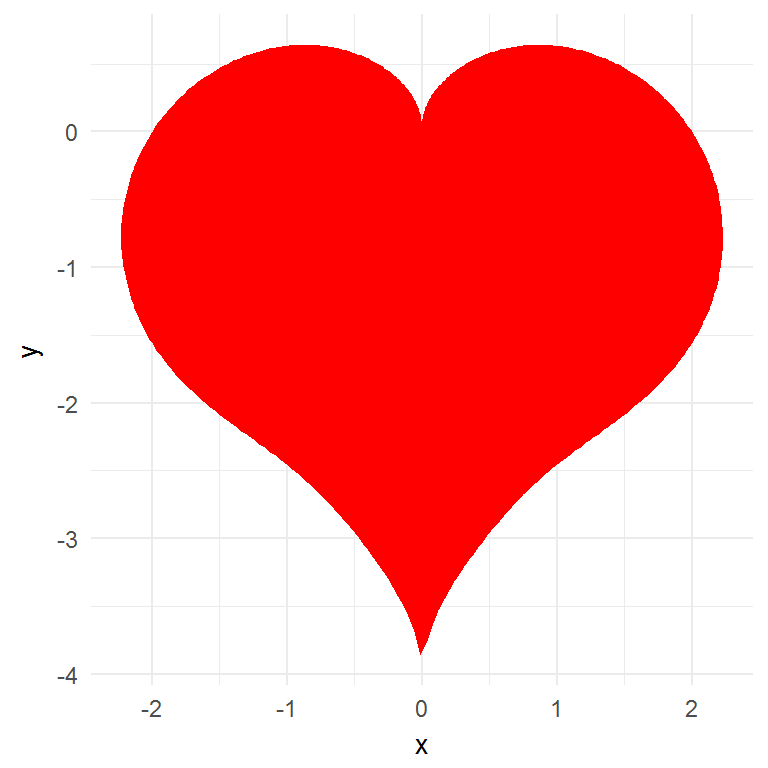

## Happy Valentine's Day!

```r
rfunc <- function(z) {
  2 - 2*sin(z) + sin(z) * sqrt(abs(cos(z))) / (sin(z) + 1.4)
} # From Wolfram MathWorld's page on heart Curves

# Polar functions usually go between 0 and 2*pi
theta <- seq(0, 2*pi, length.out = 500)

# Convert from polar coordinates to x-y coordinates
dat <- data_frame(
  theta = theta, r = rfunc(theta),
  x = r * cos(theta), y = r * sin(theta))

# Plot x and y coordinates using a polygon geom
ggplot(data = dat) +
  geom_polygon(aes(x = x, y = y), fill = "red") +
  theme_minimal()
```